# Exploring the BRFSS data

## Setup

### Load packages

```r
library(ggplot2)
library(dplyr)
```

### Load data

```r
load("brfss2013.RData")
```

## Part 1: Data

The data is collected as a **simple random sample**. Due to the method of interviewing, a **bias** in regard to **convenience** and **non-response** has to be taken into account. The sample diverges in the demographics from the real population, as known based on census. It is to assume that the same applies for the distribution in regard to race, income and education.

Findings, that are not depending on the demographics in absolute numbers can therefore be **generalized**.

As all the data is **observational**, **correlations** might be drawn from this data, but **causality can not be verified**, as confounding variables might influence findings.

### Dimension of the dataset

```r
dim(brfss2013)
```

```
## [1] 491775    330
```

The dataset contains close to a half a million observations with about 330 variables.

According to the documentation, the dataset should contain 491773 observations. Having a look around the data, two strange entries can be found quickly: A state named “0” and one called “80”

```r
unique(brfss2013$X_state)
```

```
##  [1] Alabama              Alaska               Arizona
##  [4] Arkansas             California           Colorado
##  [7] Connecticut          Delaware             District of Columbia
## [10] Florida              80                   Georgia
## [13] Hawaii               Idaho                Illinois
## [16] Indiana              Iowa                 Kansas
## [19] Kentucky             Louisiana            Maine
## [22] Maryland             Massachusetts        Michigan
## [25] 0                    Minnesota            Mississippi
## [28] Missouri             Montana              Nebraska
## [31] Nevada               New Hampshire        New Jersey
## [34] New Mexico           New York             North Carolina
## [37] North Dakota         Ohio                 Oklahoma
## [40] Oregon               Pennsylvania         Rhode Island
## [43] South Carolina       South Dakota         Tennessee
## [46] Texas                Utah                 Vermont
## [49] Virginia             Washington           West Virginia
## [52] Wisconsin            Wyoming              Guam
## [55] Puerto Rico
## 55 Levels: 0 Alabama Alaska Arizona Arkansas California ... 80
```

The strange entries seem to be empty entries and can be eliminated:

```r
brfss2013 <- brfss2013 %>%
  filter(X_state != "0") %>%
  filter(X_state != "80")
```

### How does the demographics of the sample compare to the census

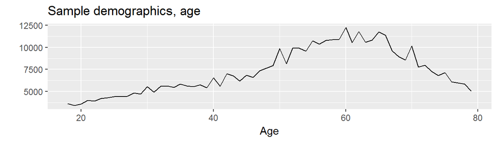

```r
# all male
age_m <- brfss2013 %>%
  select(sex, X_age80) %>%
  # as ages over 80 are collapse to 80, the chart is limited to 79
  filter(X_age80 < 80) %>%
  filter(X_age80 >= 18) %>%
  filter(sex == "Male") %>%
  group_by(X_age80)  %>%
  summarise(male=n())

# all female
age_f <- brfss2013 %>%
  select(sex, X_age80) %>%
  # as ages over 80 are collapse to 80, the chart is limited to 79
  filter(X_age80 < 80) %>%
  filter(X_age80 >= 18) %>%
  filter(sex == "Female") %>%
  group_by(X_age80)  %>%
  summarise(female=n())

# combine male and female
age = merge(age_m, age_f)

age <- age %>%
  mutate(total = male+female) %>%
  mutate(Female = female / total ) %>%
  select(X_age80, Female, total)

ggplot(age, aes(x = X_age80, y = total)) +
  geom_line() +
  xlab("Age") +
  ylab("") +
  ggtitle("Sample demographics, age")
```

The age distribution is way off the real population. The sample has a multiple of people with the age of 60 in comparison to ages 40 and younger.

And how about the distribution between female and male over age?

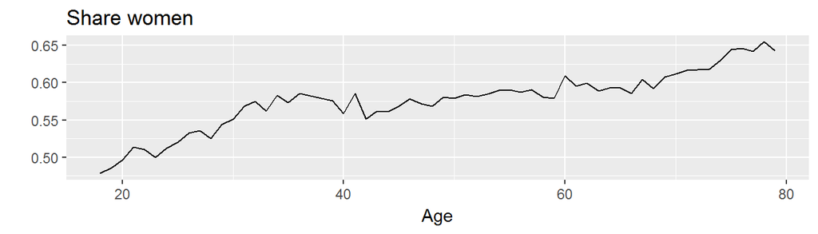

```r
ggplot(age, aes(x = X_age80, y = Female)) +
  geom_line() +
  xlab("Age") +
  ylab("")+
  ggtitle("Share women")
```

Female are over represented nearly over the complete range of ages.

It is fairly obvious, that the demographics of the sample do not accurate represent the real population as census data show, see [[^1]](https://s3.amazonaws.com/coursera-uploads/peer-review/2dHcFsRdEeW2JxKnR3RyOw/7de34c6a0f00575e5502fdd8a21deec5/intro_data_prob_project.html#fn1). Therefore, generalizations in relation to demographics would need to be adjusted.

### Can findings compared among the states

If the demographics of sample look similar between the states, findings can be compared.

```r
age_2 <- brfss2013 %>%
  filter(X_age80 < 80) %>%
  filter(X_age80 >= 18) %>%
  group_by(X_state)  %>%
  summarise(mean=mean(X_age80), median=median(X_age80), sd=sd(X_age80))  %>%
  select(X_state, mean, median, sd)

age_2
```

```
## # A tibble: 53 × 4
##                 X_state     mean median       sd
##                  <fctr>    <dbl>  <dbl>    <dbl>
## 1               Alabama 54.76296     58 15.36725
## 2                Alaska 48.59015     50 15.52166
## 3               Arizona 53.73384     57 16.39606
## 4              Arkansas 55.16850     58 15.58597
## 5            California 48.95458     50 16.70423
## 6              Colorado 51.97849     54 15.61189
## 7           Connecticut 52.20316     54 15.46717
## 8              Delaware 53.06035     55 15.95712
## 9  District of Columbia 53.71874     56 15.16624
## 10              Florida 55.80023     59 15.59547
## # ... with 43 more rows
```

The data differs within manageable ranges. Findings can therefore be compared between states.

## Part 2: Research questions

### Research question 1: Smoking over age

- Does smoking differ between gender?
- Does the habit of smoking change over the age?

### Research question 2: Overweight and Diabetes

It is commonly understood that people overweight have a higher risk of suffering from diabetes. So I’m am interested, whether the data confirms this:

- Does the data show a correlation between overweight and diabetes?
- How do the different states compare?
- Are there any outliers?

### Research question 3: Exercise and Health

- Do people feel healthier when exercising?
- Does this feeling differ between gender?
- Does this feeling change over the age?

## Part 3: Exploratory data analysis

### Research question 1: Smoking over age

#### bar plot 1, 10 year grouping

A proportional bar graph seems best to illustrate the populations behaviour in regards to smoking.

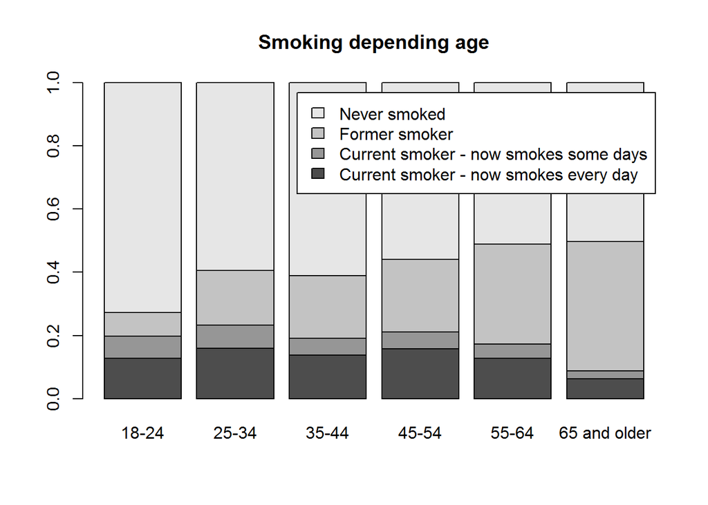

```r
smokerage <- brfss2013 %>%
  filter(!is.na(X_age_g)) %>%
  filter(!is.na(X_smoker3)) %>%
  select(X_age_g, X_smoker3) %>%
    group_by(X_age_g, X_smoker3) %>%
  summarise(count=n())

smokerage1 <- matrix(smokerage$count,nrow = 4,ncol = 6)

smokerage2 <- prop.table(smokerage1, 2)

barplot(smokerage2, names.arg=c("18-24", "25-34" , "35-44","45-54", "55-64",
"65 and older"), legend.text = c("Current smoker - now smokes every day","Current smoker - now smokes some days","Former smoker","Never smoked"), main = "Smoking depending age")
```

As I am expecting different behaviour between women and man, it is to expect that a combined visualisation would over represent the female characteristics.

#### bar plot 2, finer granularity, five year grouping for male and female separate

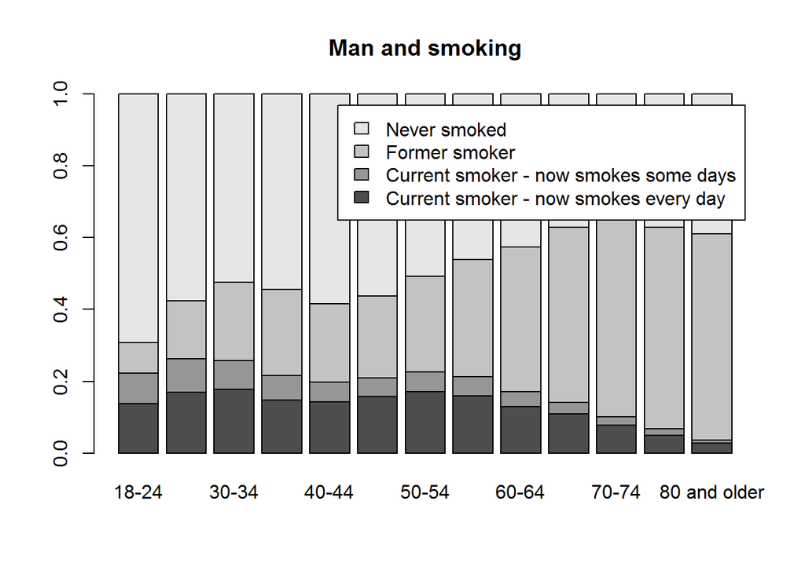

```r
smokerage <- brfss2013 %>%
  filter(!is.na(X_ageg5yr)) %>%
  filter(!is.na(X_smoker3)) %>%
  filter(sex == "Male") %>%
  select(X_ageg5yr, X_smoker3) %>%
    group_by(X_ageg5yr, X_smoker3) %>%
  summarise(count=n())

smokerage1 <- matrix(smokerage$count,nrow = 4,ncol = 13)

smokerage2 <- prop.table(smokerage1, 2)

barplot(smokerage2, names.arg=c("18-24", "25-29" , "30-34","35-39","40-44","45-49","50-54","55-59","60-64","65-69", "70-74","75-79","80 and older"), legend.text = c("Current smoker - now smokes every day","Current smoker - now smokes some days","Former smoker","Never smoked"), main = "Man and smoking")
```

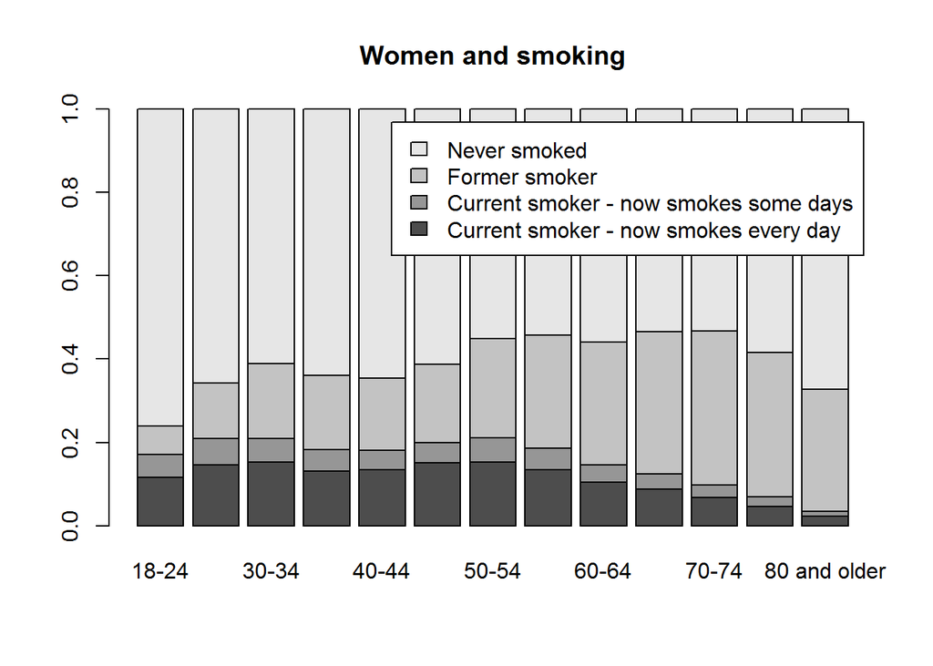

```r
smokerage <- brfss2013 %>%
  filter(!is.na(X_ageg5yr)) %>%
  filter(!is.na(X_smoker3)) %>%
  filter(sex == "Female") %>%
  select(X_ageg5yr, X_smoker3) %>%
    group_by(X_ageg5yr, X_smoker3) %>%
  summarise(count=n())

smokerage1 <- matrix(smokerage$count,nrow = 4,ncol = 13)

smokerage2 <- prop.table(smokerage1, 2)


barplot(smokerage2, names.arg=c("18-24", "25-29" , "30-34","35-39","40-44","45-49","50-54","55-59","60-64","65-69", "70-74","75-79","80 and older"), legend.text = c("Current smoker - now smokes every day","Current smoker - now smokes some days","Former smoker","Never smoked"), main = "Women and smoking")
```

Die diagrams for male and female look similar but show clearly, that women smoke less then man.

The proportional increase of people never smoked toward the highest ages might prove that smoke die younger.

### Research question 2: Overweight and Diabetes

A scatter plot might be most useful to show the correlation between overweight and diabetes in the different states.

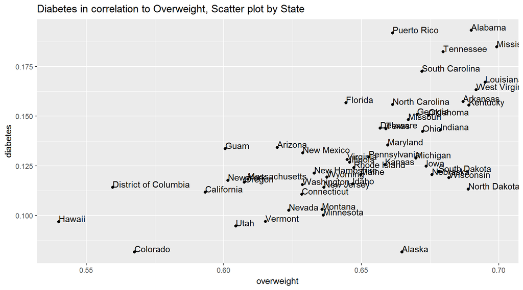

```r
# Create a table with a row per state with sum people having diabetes (diabete3 = yes)
#   and not having diabetes (diabete3 = no)
# include only observations with a value to overweight
diabetes = merge(
  brfss2013 %>%
    select(diabete3, X_rfbmi5, X_state) %>%
    filter(!is.na(X_rfbmi5)) %>%
    filter(diabete3 == "Yes")  %>%
    group_by(X_state) %>%
    summarise(count_yes=n())
  ,
  brfss2013 %>%
    select(diabete3, X_rfbmi5, X_state) %>%
    filter(!is.na(X_rfbmi5)) %>%
    filter(diabete3 == "No")  %>%
    group_by(X_state) %>%
    summarise(count_no=n())
  , by.x='X_state', by.y='X_state')

# Replace the two variables yes and no with the ration of yes
diabetes <- diabetes %>%
  mutate(diabetes = count_yes / (count_no+count_yes) ) %>%
  select(X_state, diabetes)

# Create a table with a row per state with sum people being overweight (_rfbmi5 = yes)
#   and not being overweight (_rfbmi5 = no)
# include only observations including a statement 'yes' or 'no' under diabetes
overweight = merge(
  brfss2013 %>%
    select(diabete3, X_rfbmi5, X_state) %>%
    filter(diabete3 == "Yes" | diabete3 == "No" )  %>%
    filter(X_rfbmi5 == "Yes") %>%
    group_by(X_state) %>%
    summarise(count_ow_yes=n())
  ,
  brfss2013 %>%
    select(diabete3, X_rfbmi5, X_state) %>%
    filter(diabete3 == "Yes" | diabete3 == "No" )  %>%
    filter(X_rfbmi5 == "No") %>%
    group_by(X_state) %>%
    summarise(count_ow_no=n())
  , by.x='X_state', by.y='X_state')

# Replace the two variables yes and no with the ration of yes
overweight <- overweight %>%
  mutate(overweight = count_ow_yes / (count_ow_no+count_ow_yes) ) %>%
  select(X_state, overweight)

# combine the finding to diabetes with overweight
diabetes_overweight = merge(
  overweight, diabetes, by.x='X_state', by.y='X_state')

# create a dot plot including the state name
ggplot(diabetes_overweight, aes(x= overweight, y= diabetes, label=X_state))+
  geom_point() + geom_text(aes(label = X_state),hjust=0, vjust=0)+
  ggtitle("Diabetes in correlation to Overweight, Scatter plot by State")
```

The data seems to confirm a correlation between overweight and diabetes.

Thoughts to some outliers:

**Alaska**

I guess, that people in Alaska eat different to the rest of the country. So, even thought having a fairly high rate of people overweight, the number people suffering from diabetes is very low

**Florida**

Florida being above the curve might be, because the rate of diabetes increases with age, and Florida having an older population the the rest of the country.

### Research question 3: Exercise and Health

A grouped bar plot should visualize the different feeling after exercising.

#### Age group 55 to 64

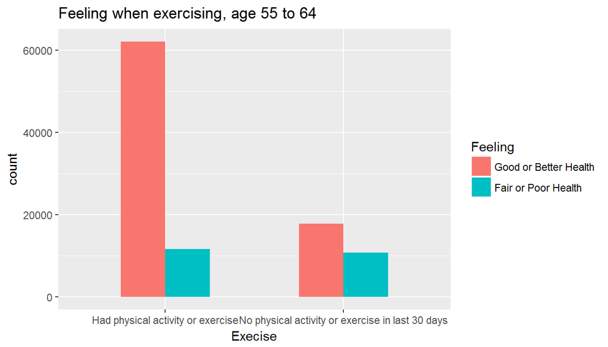

```r
health <- brfss2013 %>%
  filter(!is.na(X_rfhlth)) %>%
  filter(!is.na(X_totinda)) %>%
  filter(X_age_g == "Age 55 to 64") %>%
  select(X_totinda, X_rfhlth) %>%
  group_by(X_totinda, X_rfhlth) %>%
  summarize(count=n())

ggplot(health, aes(X_totinda, count, fill=X_rfhlth)) +
  geom_bar(position = "dodge", width=.5, stat="identity")+
    xlab("Execise")+
    labs(fill="Feeling")+
    ggtitle("Feeling when exercising, age 55 to 64")
```

It seems overwhelmingly clear, that people that hat physical activity within the 30 days see themselves healthier.

#### Age group 55 to 64, male and female

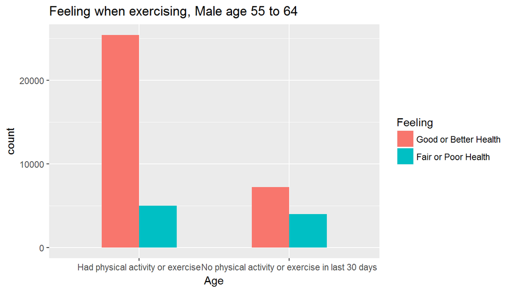

```r
health <- brfss2013 %>%
  filter(!is.na(X_rfhlth)) %>%
  filter(!is.na(X_totinda)) %>%
  filter(X_age_g == "Age 55 to 64") %>%
  select(sex, X_totinda, X_rfhlth) %>%
  group_by(sex, X_totinda, X_rfhlth) %>%
  summarize(count=n())

health %>%
  filter(sex == "Male") %>%
  ggplot(., aes(X_totinda, count, fill=X_rfhlth)) +
    geom_bar(position = "dodge", width=.5, stat="identity")+
      xlab("Age") +
      labs(fill="Feeling")+
      ggtitle("Feeling when exercising, Male age 55 to 64")
```

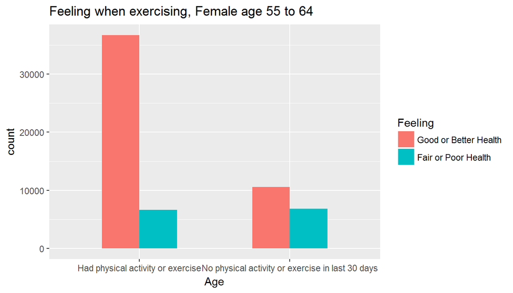

```r
health %>%
  filter(sex == "Female") %>%
  ggplot(., aes(X_totinda, count, fill=X_rfhlth)) +
    geom_bar(position = "dodge", width=.5, stat="identity")+
      xlab("Age") +
      labs(fill="Feeling")+
      ggtitle("Feeling when exercising, Female age 55 to 64")
```

The effect seems independent of sex.

#### Change over the age

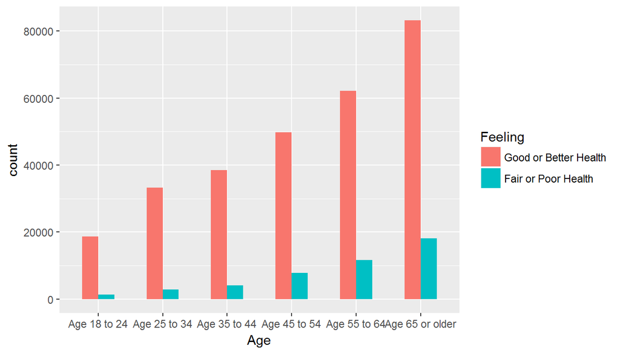

```r
health <- brfss2013 %>%
  filter(!is.na(X_rfhlth)) %>%
  filter(!is.na(X_age_g)) %>%
  select(X_totinda, X_age_g, X_rfhlth) %>%
  group_by(X_totinda, X_age_g, X_rfhlth) %>%
  summarize(count=n())


health %>%
  filter(X_totinda == "Had physical activity or exercise") %>%
  ggplot(., aes(X_age_g, count, fill=X_rfhlth)) +
    geom_bar(position = "dodge", width=.5, stat="identity")+
    xlab("Age")+
  labs(fill="Feeling")
```

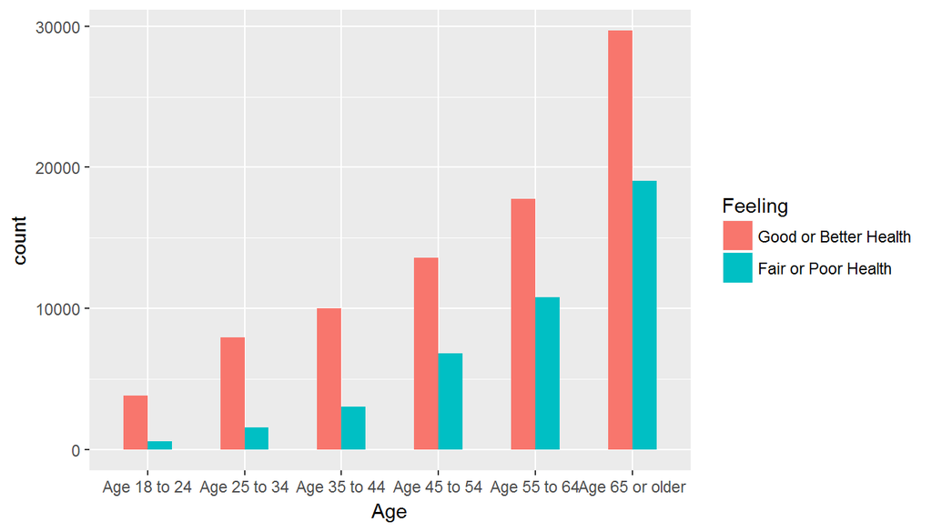

```r
health %>%
  filter(X_totinda == "No physical activity or exercise in last 30 days") %>%
  ggplot(., aes(X_age_g, count, fill=X_rfhlth)) +
    geom_bar(position = "dodge", width=.5, stat="identity")+
    xlab("Age")+
  labs(fill="Feeling")
```

[^1]: http://www.census.gov/prod/cen2010/briefs/c2010br-03.pdf , Figure 3[↩](https://s3.amazonaws.com/coursera-uploads/peer-review/2dHcFsRdEeW2JxKnR3RyOw/7de34c6a0f00575e5502fdd8a21deec5/intro_data_prob_project.html#fnref1)